# A07- ggplot

Suhail M.

June 07 2024

# **Recessions and Crime**

### **Guiding Research Question**

The goal of this project is to determine if there is any correlation between a recession and crime rates. In other words, is there more crime during a recession?

In order to do this, I have quarterly GDP data from the St. Louis FED and annual crime statistics from the FBI.

### Data Intake and Overview

#### Crime Statistics Data

- **Source :-** [Crime in the United States from the FBI](https://ucr.fbi.gov/crime-in-the-u.s/2013/crime-in-the-u.s.-2013/tables/1tabledatadecoverviewpdf/table_1_crime_in_the_united_states_by_volume_and_rate_per_100000_inhabitants_1994-2013.xls)
- **Origin and Purpose:** Annual crime statistics from the FBI’s Uniform Crime Reporting (UCR) program. This data captures various crime categories across different years.
- **Variables of Interest:**
  - `Year`: Year of observation.
  - `Violent`, `Murder_and_Manslaughter`, `Rape`, `Robbery`, `Aggravated_Assault`: Total counts of different crime types.
  - `Violent_Rate`, `Murder_and_Manslaughter_Rate`, etc.: Crime rates per 100,000 population for respective crime types.

### **Examine Each Data Source**

First, I need to load the two data sets into R

```r
library(tidyverse)
```

```r
GDP <- read.csv("C:\\Users\\hp\\Downloads\\MEB\\4007 suhail\\Final-Project-Stat-184\\GDPC1.csv")

# Display structure and summary
str(GDP)
```

```
'data.frame':   309 obs. of  2 variables:
 $ DATE : chr  "1947-01-01" "1947-04-01" "1947-07-01" "1947-10-01" ...
 $ GDPC1: num  2183 2177 2172 2206 2240 ...
```

```r
summary(GDP)
```

```
     DATE               GDPC1
 Length:309         Min.   : 2172
 Class :character   1st Qu.: 4748
 Mode  :character   Median : 8604
                    Mean   :10010
                    3rd Qu.:15671
                    Max.   :22750
```

```r
head(GDP)
```

|  | DATE | GDPC1 |
| --- | --- | --- |
| 1 | 1947-01-01 | 2182.681 |
| 2 | 1947-04-01 | 2176.892 |
| 3 | 1947-07-01 | 2172.432 |
| 4 | 1947-10-01 | 2206.452 |
| 5 | 1948-01-01 | 2239.682 |
| 6 | 1948-04-01 | 2276.690 |

```r
# Check for missing values and convert to numeric
GDP$GDPC1 <- as.numeric(GDP$GDPC1)

# Check for missing values in GDPC1
sum(is.na(GDP$GDPC1))  # Check if there are any NA values
```

```
[1] 0
```

[figure not shown]

```r
# Plot boxplot if there are no missing values
if (!anyNA(GDP$GDPC1)) {
  boxplot(GDP$GDPC1, main = "Boxplot of Quarterly GDP Growth Rate")
} else {
  cat("There are missing values in GDPC1 column. Please handle them before plotting.")
}
```

```r
CRIME <-  read.csv("C:\\Users\\hp\\Downloads\\MEB\\4007 suhail\\Final-Project-Stat-184\\CRIME.csv")

Crime2<-CRIME[-c(1,2,24,25,26,27,28,29,30,31,32,33,34,35,36,37),]  #Delete unnecessary rows from Crime and rename the table

colnames(Crime2)[1] <- "Year"                                      #Renaming the column names because they were wrong
colnames(Crime2)[2] <- "Population"
colnames(Crime2)[3] <- "Violent"
colnames(Crime2)[4] <- "Violent_Rate"
colnames(Crime2)[5] <- "Murder_and_Manslaughter"
colnames(Crime2)[6] <- "Murder_and_Manslaughter_Rate"
colnames(Crime2)[7] <- "Rape"
colnames(Crime2)[8] <- "Rape_Rate"
colnames(Crime2)[9] <- "Robbery"
colnames(Crime2)[10] <- "Robbery_Rate"
colnames(Crime2)[11] <- "Aggravated_Assault"
colnames(Crime2)[12] <- "Aggravated_Assault_Rate"
colnames(Crime2)[13] <- "Property"
colnames(Crime2)[14] <- "Property_Crime"
colnames(Crime2)[15] <- "Burglary"
colnames(Crime2)[16] <- "Burglary_Rate"
colnames(Crime2)[17] <- "Larceny"
colnames(Crime2)[18] <- "Larceny_Rate"
colnames(Crime2)[19] <- "Motor_Vehicle_Theft"
colnames(Crime2)[20] <- "Motor_Vehicle_Theft_Rate"

Crime3<- Crime2[-c(1),]                      #Delete the first row because it had header information instead of data

Crime3$X.19<- NULL                           # Delete the last four columns because they all had NA for data
Crime3$X.20<-NULL
Crime3$X.21 <-NULL
Crime3$X.22<-NULL

Crime3[1] <- lapply(Crime3, as.character)    #convert Year to a character so it can be joinged with GDP Year
CRIME_Final <- Crime3                        #Rename the finished clean table CRIME_Final

head(CRIME_Final)                            #create neat table for CRIME_Final
```

|  | Year | Population | Violent | Violent_Rate | Murder_and_Manslaughter | Murder_and_Manslaughter_Rate | Rape | Rape_Rate | Robbery | Robbery_Rate | Aggravated_Assault | Aggravated_Assault_Rate | Property | Property_Crime | Burglary | Burglary_Rate | Larceny | Larceny_Rate | Motor_Vehicle_Theft | Motor_Vehicle_Theft_Rate |
| --- | --- | --- | --- | --- | --- | --- | --- | --- | --- | --- | --- | --- | --- | --- | --- | --- | --- | --- | --- | --- |
| 4 | 1994 | 260,327,021 | 1,857,670 | 713.6 | 23,326 | 9 | 102,216 | 39.3 | 618,949 | 237.8 | 1,113,179 | 427.6 | 12,131,873 | 4,660.20 | 2,712,774 | 1,042.10 | 7,879,812 | 3,026.90 | 1,539,287 | 591.3 |
| 5 | 1995 | 262,803,276 | 1,798,792 | 684.5 | 21,606 | 8.2 | 97,470 | 37.1 | 580,509 | 220.9 | 1,099,207 | 418.3 | 12,063,935 | 4,590.50 | 2,593,784 | 987 | 7,997,710 | 3,043.20 | 1,472,441 | 560.3 |
| 6 | 1996 | 265,228,572 | 1,688,540 | 636.6 | 19,645 | 7.4 | 96,252 | 36.3 | 535,594 | 201.9 | 1,037,049 | 391 | 11,805,323 | 4,451.00 | 2,506,400 | 945 | 7,904,685 | 2,980.30 | 1,394,238 | 525.7 |
| 7 | 1997 | 267,783,607 | 1,636,096 | 611 | 18,208 | 6.8 | 96,153 | 35.9 | 498,534 | 186.2 | 1,023,201 | 382.1 | 11,558,475 | 4,316.30 | 2,460,526 | 918.8 | 7,743,760 | 2,891.80 | 1,354,189 | 505.7 |
| 8 | 1998 | 270,248,003 | 1,533,887 | 567.6 | 16,974 | 6.3 | 93,144 | 34.5 | 447,186 | 165.5 | 976,583 | 361.4 | 10,951,827 | 4,052.50 | 2,332,735 | 863.2 | 7,376,311 | 2,729.50 | 1,242,781 | 459.9 |
| 9 | 1999 | 272,690,813 | 1,426,044 | 523 | 15,522 | 5.7 | 89,411 | 32.8 | 409,371 | 150.1 | 911,740 | 334.3 | 10,208,334 | 3,743.60 | 2,100,739 | 770.4 | 6,955,520 | 2,550.70 | 1,152,075 | 422.5 |

```r
# Display structure and summary
str(CRIME_Final)
```

```
'data.frame':   27 obs. of  20 variables:
 $ Year                        : chr  "1994" "1995" "1996" "1997" ...
 $ Population                  : chr  "260,327,021" "262,803,276" "265,228,572" "267,783,607" ...
 $ Violent                     : chr  "1,857,670" "1,798,792" "1,688,540" "1,636,096" ...
 $ Violent_Rate                : chr  "713.6" "684.5" "636.6" "611" ...
 $ Murder_and_Manslaughter     : chr  "23,326" "21,606" "19,645" "18,208" ...
 $ Murder_and_Manslaughter_Rate: chr  "9" "8.2" "7.4" "6.8" ...
 $ Rape                        : chr  "102,216" "97,470" "96,252" "96,153" ...
 $ Rape_Rate                   : chr  "39.3" "37.1" "36.3" "35.9" ...
 $ Robbery                     : chr  "618,949" "580,509" "535,594" "498,534" ...
 $ Robbery_Rate                : chr  "237.8" "220.9" "201.9" "186.2" ...
 $ Aggravated_Assault          : chr  "1,113,179" "1,099,207" "1,037,049" "1,023,201" ...
 $ Aggravated_Assault_Rate     : chr  "427.6" "418.3" "391" "382.1" ...
 $ Property                    : chr  "12,131,873" "12,063,935" "11,805,323" "11,558,475" ...
 $ Property_Crime              : chr  "4,660.20" "4,590.50" "4,451.00" "4,316.30" ...
 $ Burglary                    : chr  "2,712,774" "2,593,784" "2,506,400" "2,460,526" ...
 $ Burglary_Rate               : chr  "1,042.10" "987" "945" "918.8" ...
 $ Larceny                     : chr  "7,879,812" "7,997,710" "7,904,685" "7,743,760" ...
 $ Larceny_Rate                : chr  "3,026.90" "3,043.20" "2,980.30" "2,891.80" ...
 $ Motor_Vehicle_Theft         : chr  "1,539,287" "1,472,441" "1,394,238" "1,354,189" ...
 $ Motor_Vehicle_Theft_Rate    : chr  "591.3" "560.3" "525.7" "505.7" ...
```

```r
summary(CRIME_Final)
```

```
     Year            Population          Violent          Violent_Rate       Murder_and_Manslaughter
 Length:27          Length:27          Length:27          Length:27          Length:27
 Class :character   Class :character   Class :character   Class :character   Class :character
 Mode  :character   Mode  :character   Mode  :character   Mode  :character   Mode  :character
 Murder_and_Manslaughter_Rate     Rape            Rape_Rate           Robbery          Robbery_Rate
 Length:27                    Length:27          Length:27          Length:27          Length:27
 Class :character             Class :character   Class :character   Class :character   Class :character
 Mode  :character             Mode  :character   Mode  :character   Mode  :character   Mode  :character
 Aggravated_Assault Aggravated_Assault_Rate   Property         Property_Crime       Burglary
 Length:27          Length:27               Length:27          Length:27          Length:27
 Class :character   Class :character        Class :character   Class :character   Class :character
 Mode  :character   Mode  :character        Mode  :character   Mode  :character   Mode  :character
 Burglary_Rate        Larceny          Larceny_Rate       Motor_Vehicle_Theft Motor_Vehicle_Theft_Rate
 Length:27          Length:27          Length:27          Length:27           Length:27
 Class :character   Class :character   Class :character   Class :character    Class :character
 Mode  :character   Mode  :character   Mode  :character   Mode  :character    Mode  :character
```

```r
# Convert crime count variables to numeric
CRIME_Final[, c("Violent", "Murder_and_Manslaughter", "Rape", "Robbery", "Aggravated_Assault")] <-
  lapply(CRIME_Final[, c("Violent", "Murder_and_Manslaughter", "Rape", "Robbery", "Aggravated_Assault")],
         function(x) as.numeric(gsub(",", "", x)))

# Convert crime rate variables to numeric
CRIME_Final[, c("Violent_Rate", "Murder_and_Manslaughter_Rate", "Rape_Rate", "Robbery_Rate", "Aggravated_Assault_Rate")] <-
  lapply(CRIME_Final[, c("Violent_Rate", "Murder_and_Manslaughter_Rate", "Rape_Rate", "Robbery_Rate", "Aggravated_Assault_Rate")],
         function(x) as.numeric(x))

# Display structure and summary after conversion
str(CRIME_Final)
```

```
'data.frame':   27 obs. of  20 variables:
 $ Year                        : chr  "1994" "1995" "1996" "1997" ...
 $ Population                  : chr  "260,327,021" "262,803,276" "265,228,572" "267,783,607" ...
 $ Violent                     : num  1857670 1798792 1688540 1636096 1533887 ...
 $ Violent_Rate                : num  714 684 637 611 568 ...
 $ Murder_and_Manslaughter     : num  23326 21606 19645 18208 16974 ...
 $ Murder_and_Manslaughter_Rate: num  9 8.2 7.4 6.8 6.3 5.7 5.5 5.6 5.6 5.7 ...
 $ Rape                        : num  102216 97470 96252 96153 93144 ...
 $ Rape_Rate                   : num  39.3 37.1 36.3 35.9 34.5 32.8 32 31.8 33.1 32.3 ...
 $ Robbery                     : num  618949 580509 535594 498534 447186 ...
 $ Robbery_Rate                : num  238 221 202 186 166 ...
 $ Aggravated_Assault          : num  1113179 1099207 1037049 1023201 976583 ...
 $ Aggravated_Assault_Rate     : num  428 418 391 382 361 ...
 $ Property                    : chr  "12,131,873" "12,063,935" "11,805,323" "11,558,475" ...
 $ Property_Crime              : chr  "4,660.20" "4,590.50" "4,451.00" "4,316.30" ...
 $ Burglary                    : chr  "2,712,774" "2,593,784" "2,506,400" "2,460,526" ...
 $ Burglary_Rate               : chr  "1,042.10" "987" "945" "918.8" ...
 $ Larceny                     : chr  "7,879,812" "7,997,710" "7,904,685" "7,743,760" ...
 $ Larceny_Rate                : chr  "3,026.90" "3,043.20" "2,980.30" "2,891.80" ...
 $ Motor_Vehicle_Theft         : chr  "1,539,287" "1,472,441" "1,394,238" "1,354,189" ...
 $ Motor_Vehicle_Theft_Rate    : chr  "591.3" "560.3" "525.7" "505.7" ...
```

```r
summary(CRIME_Final)
```

```
     Year            Population           Violent         Violent_Rate   Murder_and_Manslaughter
 Length:27          Length:27          Min.   :1163146   Min.   :367.9   Min.   :14196
 Class :character   Class :character   1st Qu.:1351540   1st Qu.:451.9   1st Qu.:15491
 Mode  :character   Mode  :character   Median :1423324   Median :477.6   Median :16347
                                       Mean   :1439004   Mean   :501.9   Mean   :16864
                                       3rd Qu.:1463082   3rd Qu.:534.1   3rd Qu.:17173
                                       Max.   :1857670   Max.   :713.6   Max.   :23326
                                       NA's   :7         NA's   :7       NA's   :7
 Murder_and_Manslaughter_Rate      Rape          Rape_Rate        Robbery        Robbery_Rate
 Min.   :4.500                Min.   : 79770   Min.   :25.20   Min.   :345031   Min.   :109.1
 1st Qu.:5.300                1st Qu.: 89369   1st Qu.:29.62   1st Qu.:406380   1st Qu.:135.8
 Median :5.600                Median : 92652   Median :31.90   Median :419122   Median :146.0
 Mean   :5.875                Mean   : 91777   Mean   :31.87   Mean   :437423   Mean   :152.7
 3rd Qu.:5.925                3rd Qu.: 95126   3rd Qu.:33.45   3rd Qu.:447805   3rd Qu.:153.9
 Max.   :9.000                Max.   :102216   Max.   :39.30   Max.   :618949   Max.   :237.8
 NA's   :7                    NA's   :7        NA's   :7       NA's   :7        NA's   :7
 Aggravated_Assault Aggravated_Assault_Rate   Property         Property_Crime       Burglary
 Min.   : 724149    Min.   :229.1           Length:27          Length:27          Length:27
 1st Qu.: 835891    1st Qu.:274.3           Class :character   Class :character   Class :character
 Median : 870227    Median :293.7           Mode  :character   Mode  :character   Mode  :character
 Mean   : 892940    Mean   :311.5
 3rd Qu.: 927951    3rd Qu.:341.1
 Max.   :1113179    Max.   :427.6
 NA's   :7          NA's   :7
 Burglary_Rate        Larceny          Larceny_Rate       Motor_Vehicle_Theft Motor_Vehicle_Theft_Rate
 Length:27          Length:27          Length:27          Length:27           Length:27
 Class :character   Class :character   Class :character   Class :character    Class :character
 Mode  :character   Mode  :character   Mode  :character   Mode  :character    Mode  :character
```

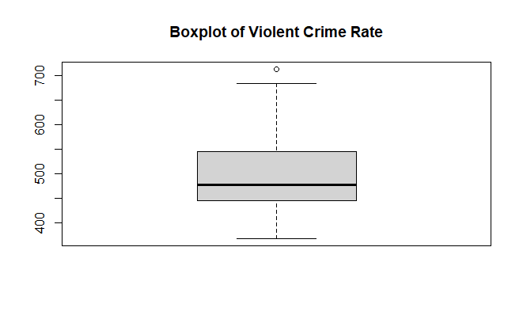

```r
# Check for outliers in crime rates
boxplot(CRIME_Final$Violent_Rate, main = "Boxplot of Violent Crime Rate")
```

### **Graphics**

[figure not shown]

```r
# Convert DATE to Date format
GDP$DATE <- as.Date(GDP$DATE)

# Load ggplot2 package
library(ggplot2)

# Create the time series plot
ggplot(GDP, aes(x = DATE, y = GDPC1)) +
  geom_line() +
  labs(title = "US Quarterly GDP Growth Rate",
       x = "Date",
       y = "Growth Rate (%)")
```

Violent Crime Rate Over Time

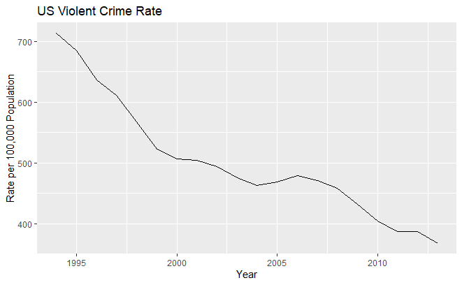

```r
CRIME_Final$Year <- as.numeric(CRIME_Final$Year)
CRIME_Final$Violent_Rate <- as.numeric(gsub(",", "", CRIME_Final$Violent_Rate))  # Remove commas and convert to numeric

# Create the line plot
ggplot(CRIME_Final, aes(x = Year, y = Violent_Rate)) +
  geom_line() +
  labs(title = "US Violent Crime Rate",
       x = "Year",
       y = "Rate per 100,000 Population")
```

In order to find which quarters were in a recession, I will calculate the percentage change for GDP. Then I can filter out all of the positive values to get only recession entries.

```r
#calculate pecentage change of GDP and only display the values for a negative value to show recession years.

GDP_Recession <- GDP%>%                                    #name the table GDP_Recessions and use the GDP data
  mutate(pChange=(GDPC1-lag(GDPC1))/lag(GDPC1)*100)%>% #creates the percentage change variable
  filter(pChange<0) %>%                                #Only display the negative percentage change values
  na.omit()                                            #omit any entries that say NA

head(GDP_Recession)
```

|  | DATE | GDPC1 | pChange |
| --- | --- | --- | --- |
| 1 | 1947-04-01 | 2176.892 | -0.2652243 |
| 2 | 1947-07-01 | 2172.432 | -0.2048792 |
| 3 | 1949-01-01 | 2260.807 | -1.3766138 |
| 4 | 1949-04-01 | 2253.128 | -0.3396575 |
| 5 | 1949-10-01 | 2257.352 | -0.8378053 |
| 6 | 1953-07-01 | 2902.785 | -0.5625160 |

Now I will finalize my GDP data. GDP is reported quarterly, but I need to make it annual so that it will match with the Crime table. To make it annual data, I am averaging the percentage change values for each year.

```r
#Crime data is only yearly. so need to get the GDP_Recession data into yearly. To do this, find the yearly average rate for GDP_Recession. Probably better to tell an actual recession because it'll give a closer estimate of consecutive periods and official recessions.

library(stringi)                                         #Required for stri_extract_last_regex

GDP_Recession2 <- GDP_Recession %>%                      #Extracts the year (last four digits) from the date
  mutate(Year=(stri_extract_last_regex(DATE, "\\d{4}")))

GDP_Final<-
group_by(GDP_Recession2,Year ) %>%                       #Finds the average annual percent change in GDP
  summarize(GDP_Rate= mean(pChange))


#create neat table for GDP_FinalNext, I need to take some steps to clean my Crime data-set so that R will be able to use it
head(GDP_Final)
```

| Year | GDP_Rate |
| --- | --- |
| 1947 | -0.2350518 |
| 1949 | -0.8513589 |
| 1953 | -1.0381173 |
| 1954 | -0.4775705 |
| 1956 | -0.2388730 |
| 1957 | -0.6268393 |

Now I have two tables that are ready to be joined. I will use the year to match them so that each case is a year with crime statistics and a GDP percentage change value

```r
#Need to Join the two tables so each year has a percentage change and crime statistics

# Convert GDP_Final$Year to numeric
GDP_Final$Year <- as.numeric(GDP_Final$Year)

# Now perform the full join
Total <- CRIME_Final %>%                #Join CRIME_Final and GDP_Final by year
  full_join(GDP_Final, by = "Year") %>%
  na.omit()

head(Total)             #create neat table for Total
```

|  | Year | Population | Violent | Violent_Rate | Murder_and_Manslaughter | Murder_and_Manslaughter_Rate | Rape | Rape_Rate | Robbery | Robbery_Rate | Aggravated_Assault | Aggravated_Assault_Rate | Property | Property_Crime | Burglary | Burglary_Rate | Larceny | Larceny_Rate | Motor_Vehicle_Theft | Motor_Vehicle_Theft_Rate | GDP_Rate |
| --- | --- | --- | --- | --- | --- | --- | --- | --- | --- | --- | --- | --- | --- | --- | --- | --- | --- | --- | --- | --- | --- |
| 8 | 2001 | 285,317,559 | 1439480 | 504.5 | 16037 | 5.6 | 90863 | 31.8 | 423557 | 148.5 | 909023 | 318.6 | 10,437,189 | 3,658.10 | 2,116,531 | 741.8 | 7,092,267 | 2,485.70 | 1,228,391 | 430.5 | -0.3642190 |
| 15 | 2008 | 304,059,724 | 1394461 | 458.6 | 16465 | 5.4 | 90750 | 29.8 | 443563 | 145.9 | 843683 | 277.5 | 9,774,152 | 3,214.60 | 2,228,887 | 733 | 6,586,206 | 2,166.10 | 959,059 | 315.4 | -1.0470163 |
| 16 | 2009 | 307,006,550 | 1325896 | 431.9 | 15399 | 5.0 | 89241 | 29.1 | 408742 | 133.1 | 812514 | 264.7 | 9,337,060 | 3,041.30 | 2,203,313 | 717.7 | 6,338,095 | 2,064.50 | 795,652 | 259.2 | -0.6567626 |
| 18 | 2011 | 311,587,816 | 1206005 | 387.1 | 14661 | 4.7 | 84175 | 27.0 | 354746 | 113.9 | 752423 | 241.5 | 9,052,743 | 2,905.40 | 2,185,140 | 701.3 | 6,151,095 | 1,974.10 | 716,508 | 230 | -0.1297588 |

### **Based on the initial EDA:**

- The graphics will help us to visualize any potential patterns or trends in GDP growth rates and crime rates.
- Observations from these plots will guide us further analysis into the correlation between recessions and crime rates.